# Entrega 4 - Clustering

Minería de Datos

Andrés Campos Cuiña

11/04/2022

# Introducción

En primer lugar, definimos el directorio de trabajo:

```r
setwd("c:/Users/Andres/Google Drive/USC/MaBD/Mineria de Datos/Practicas/Practica4/")
```

En segundo lugar, cargamos las librerías necesarias:

```r
library(ggplot2)
library(caret)
library(gridExtra)
library(fastcluster)
library(pvclust)
library(cluster)
library(dbscan)
library(fpc)
```

# Ejercicios

## Ejercicio 1

**Examina el conjunto de datos y determina el número y tipo de los atributos, y el número de instancias.**

Cargamos los datos.

```r
proteindata <- read.delim("./data/proteindata.txt", row.names = 1)
```

Lo examinamos.

```r
str(proteindata)
```

```
## 'data.frame':    25 obs. of  9 variables:
##  $ RedMeat  : num  10.1 8.9 13.5 7.8 9.7 10.6 8.4 9.5 18 10.2 ...
##  $ WhiteMeat: num  1.4 14 9.3 6 11.4 10.8 11.6 4.9 9.9 3 ...
##  $ Eggs     : num  0.5 4.3 4.1 1.6 2.8 3.7 3.7 2.7 3.3 2.8 ...
##  $ Milk     : num  8.9 19.9 17.5 8.3 12.5 25 11.1 33.7 19.5 17.6 ...
##  $ Fish     : num  0.2 2.1 4.5 1.2 2 9.9 5.4 5.8 5.7 5.9 ...
##  $ Cereals  : num  42.3 28 26.6 56.7 34.3 21.9 24.6 26.3 28.1 41.7 ...
##  $ Starch   : num  0.6 3.6 5.7 1.1 5 4.8 6.5 5.1 4.8 2.2 ...
##  $ Nuts     : num  5.5 1.3 2.1 3.7 1.1 0.7 0.8 1 2.4 7.8 ...
##  $ FruitVeg : num  1.7 4.3 4 4.2 4 2.4 3.6 1.4 6.5 6.5 ...
```

Como se puede observar, hay **9 variables**, todas ellas con tipo de dato **numeric**. Hay **25 instancias** en el DataFrame (25 filas) y se puede acceder a cada una de ellas a través del nombre del país que representan en inglés.

Comprobamos si hay valores faltantes.

```r
apply(proteindata, 2, function(x){ sum(is.na(x)) })
```

```
##   RedMeat WhiteMeat      Eggs      Milk      Fish   Cereals    Starch      Nuts
##         0         0         0         0         0         0         0         0
##  FruitVeg
##         0
```

No hay valores ausentes, por lo que parece que no es necesario ningún tipo de preprocesado de los datos.

## Ejercicio 2

**Comprueba el resultado de la operación anterior de forma gráfica. Utiliza los gráficos de dispersión y de cajas, para comparar los resultados antes y después del escalado.**

Escalamos y centramos los datos mediante la función `scale()`.

```r
proteindata.scaled <- as.data.frame(scale(proteindata))
```

Graficamos mediante gráficos de dispersión.

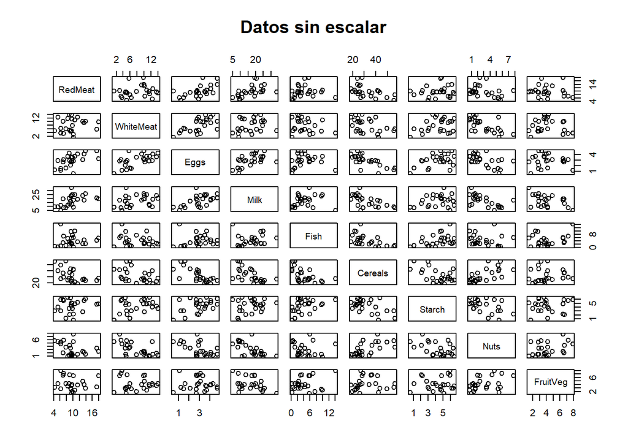

```r
plot(proteindata, main = "Datos sin escalar")
```

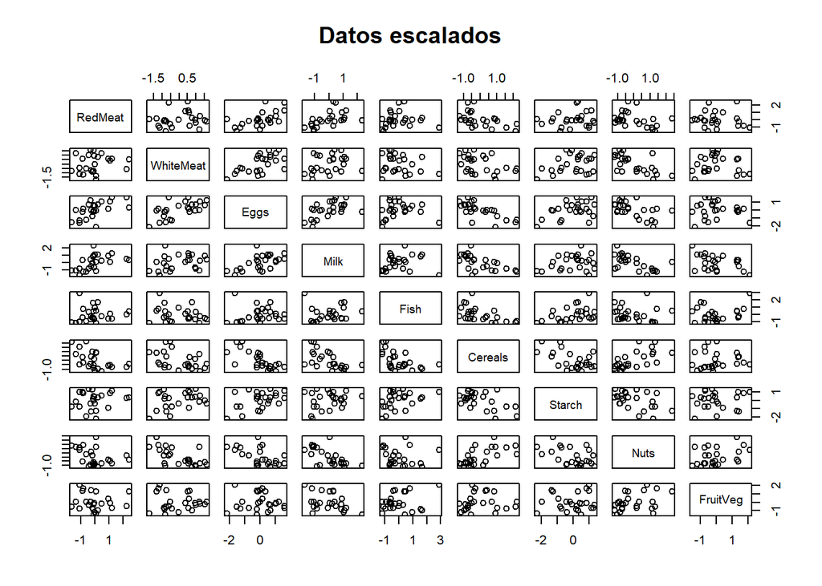

```r
plot(proteindata.scaled, main = "Datos escalados")
```

Se aprecia como cambian las escalas en las que se encuentran nuestros datos. Lo mostramos también mediante un diagrama de cajas.

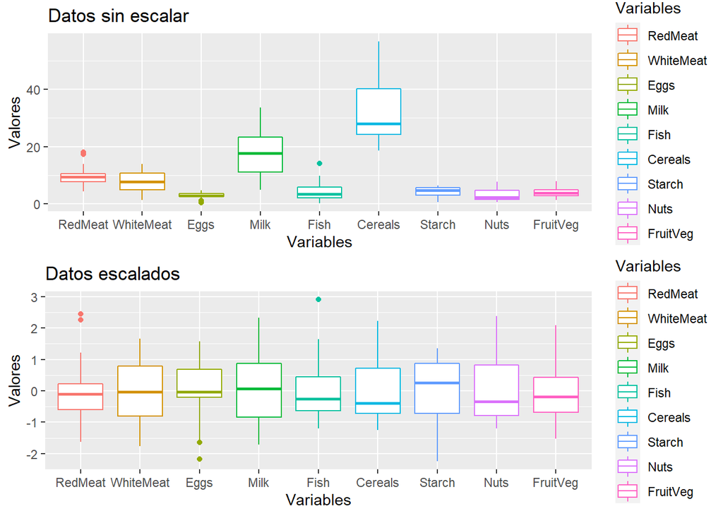

```r
proteindata.stacked <- stack(proteindata)
proteindata.scaled.stacked <- stack(proteindata.scaled)

p1 <- ggplot(
  data = proteindata.stacked,
  aes(
    x = ind,
    y = values,
    color = ind
  )
) +
geom_boxplot() +
labs(
  title = "Datos sin escalar",
  x = "Variables",
  y = "Valores",
  color = 'Variables'
)

p2 <- ggplot(
  data = proteindata.scaled.stacked,
  aes(
    x = ind,
    y = values,
    color = ind
  )
) +
geom_boxplot() +
labs(
  title = "Datos escalados",
  x = "Variables",
  y = "Valores",
  color = 'Variables'
)

grid.arrange(p1, p2, nrow=2)
```

## Ejercicio 3

**Como hemos visto en clase, existen varias formas de realizar el clustering aglomerativo en función de cómo se defina la distancia entre cluster:**

**1. Cambia el parámetro method de la función `hclust()` y obtén los distintos dendrogramas.**

**2. Prueba a cambiar también la forma de calcular la distancia y comprueba como afecta al resultado del clustering.**

**3. Selecciona alguna de las combinaciones anteriores e interpreta los resultados obtenidos.**

**4. ¿Cómo podríamos realizar un clustering jerárquicos por atributos? ¿Qué información podría relevar este tipo de clustering?**

Antes de nada, obtenemos la matriz de distancias.

```r
proteindata.dist.euclidean <- dist(proteindata.scaled, method = "euclidian")
```

**Apartado 1**

Obtenemos los distintos dendogramas que se pueden obtener modificando el parámetro `method` de la función `hclust()`.

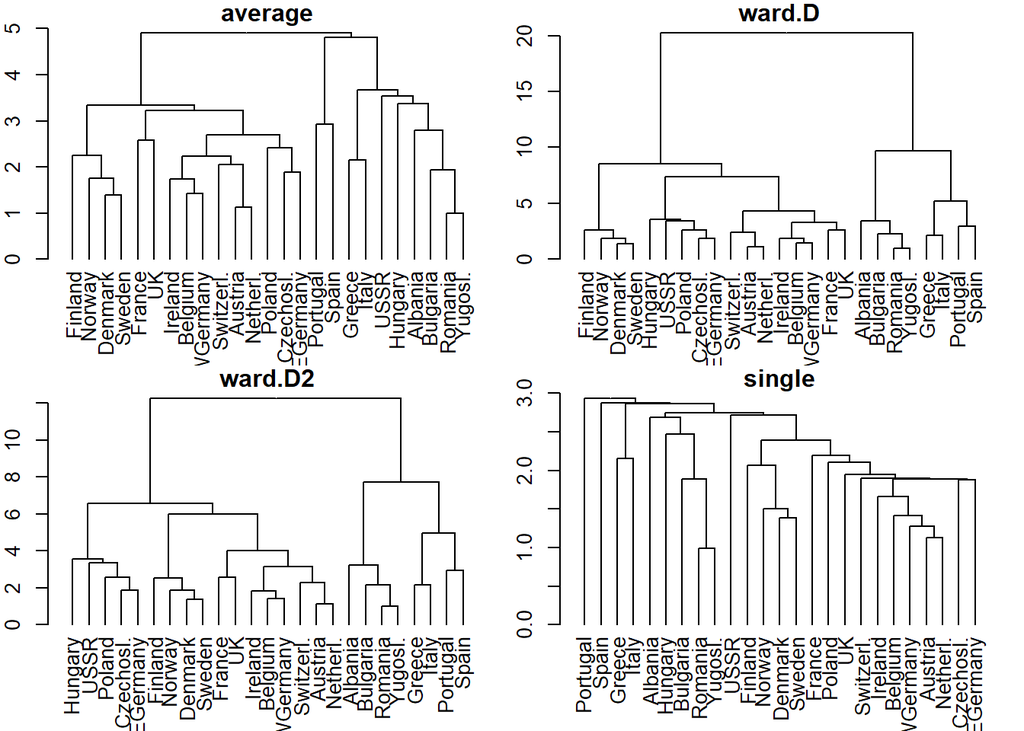

```r
par(mfrow = c(2, 2), mar = c(4, 2, 1, 1))
plot(
  as.dendrogram(hclust(proteindata.dist.euclidean, method = "average")),
  main = "average")
plot(
  as.dendrogram(hclust(proteindata.dist.euclidean, method = "ward.D")),
  main ="ward.D")
plot(
  as.dendrogram(hclust(proteindata.dist.euclidean, method = "ward.D2")),
  main = "ward.D2")
plot(
  as.dendrogram(hclust(proteindata.dist.euclidean, method = "single")),
  main = "single")
```

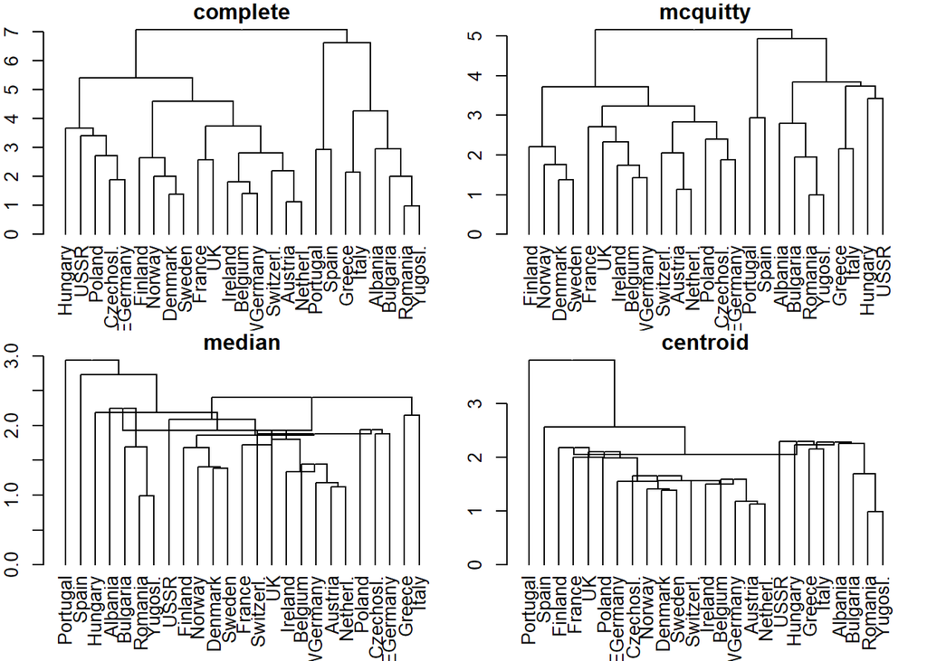

```r
par(mfrow = c(2, 2), mar = c(4, 2, 1, 1))
plot(
  as.dendrogram(hclust(proteindata.dist.euclidean, method = "complete")),
  main = "complete")
plot(
  as.dendrogram(hclust(proteindata.dist.euclidean, method = "mcquitty")),
  main = "mcquitty")
plot(
  as.dendrogram(hclust(proteindata.dist.euclidean, method = "median")),
  main = "median")
plot(
  as.dendrogram(hclust(proteindata.dist.euclidean, method = "centroid")),
  main = "centroid")
```

**Apartado 2**

Probamos la distancia Manhattan en lugar de la distancia euclídea y vemos cómo afecta al resultado del clustering.

Antes de nada calculamos una nueva matriz de distancias que utilice esta distancia.

```r
proteindata.dist.manhattan <- dist(proteindata.scaled, method = "manhattan")
```

Mostramos los dendogramas obtenidos por cada uno de los diferentes métodos para las dos distancias diferentes.

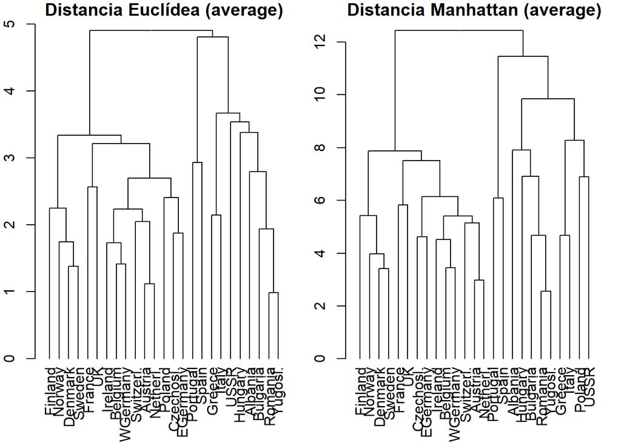

```r
par(mfrow = c(1, 2), mar = c(4, 2, 1, 1))
plot(
  as.dendrogram(hclust(proteindata.dist.euclidean, method = "average")),
  main = "Distancia Euclídea (average)")
plot(
  as.dendrogram(hclust(proteindata.dist.manhattan, method = "average")),
  main ="Distancia Manhattan (average)")
```

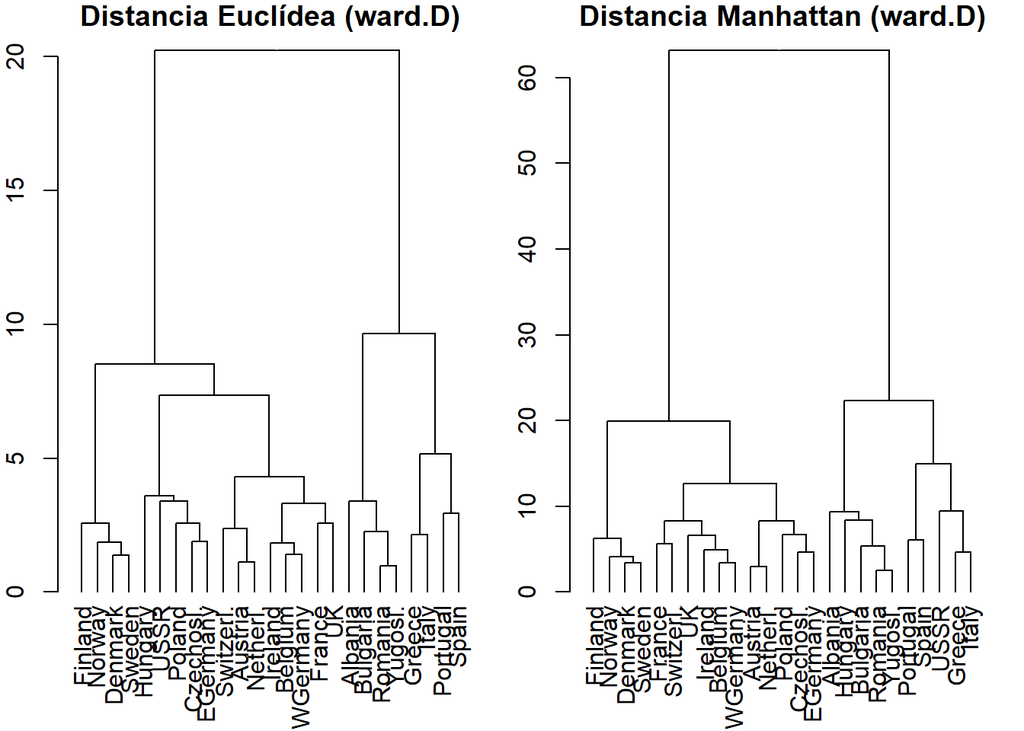

```r
par(mfrow = c(1, 2), mar = c(4, 2, 1, 1))
plot(
  as.dendrogram(hclust(proteindata.dist.euclidean, method = "ward.D")),
  main = "Distancia Euclídea (ward.D)")
plot(
  as.dendrogram(hclust(proteindata.dist.manhattan, method = "ward.D")),
  main ="Distancia Manhattan (ward.D)")
```

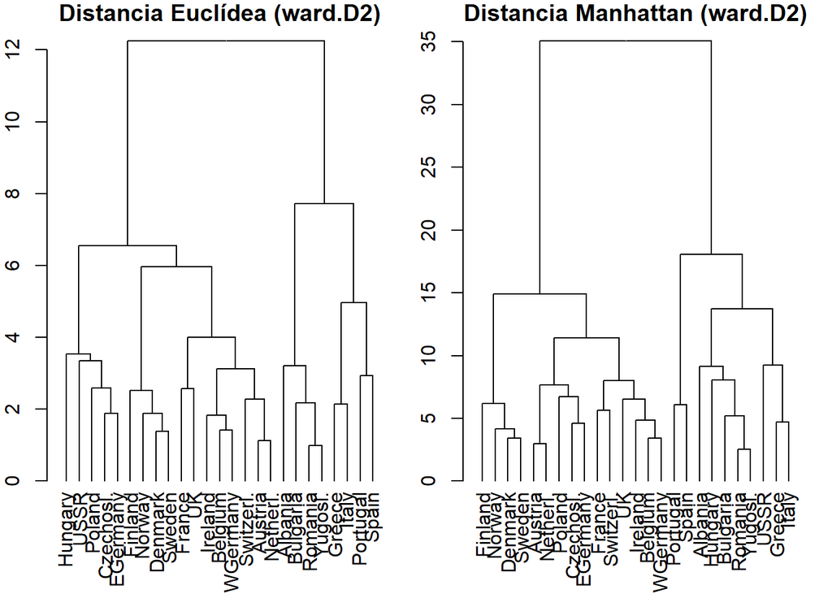

```r
par(mfrow = c(1, 2), mar = c(4, 2, 1, 1))
plot(
  as.dendrogram(hclust(proteindata.dist.euclidean, method = "ward.D2")),
  main = "Distancia Euclídea (ward.D2)")
plot(
  as.dendrogram(hclust(proteindata.dist.manhattan, method = "ward.D2")),
  main ="Distancia Manhattan (ward.D2)")
```

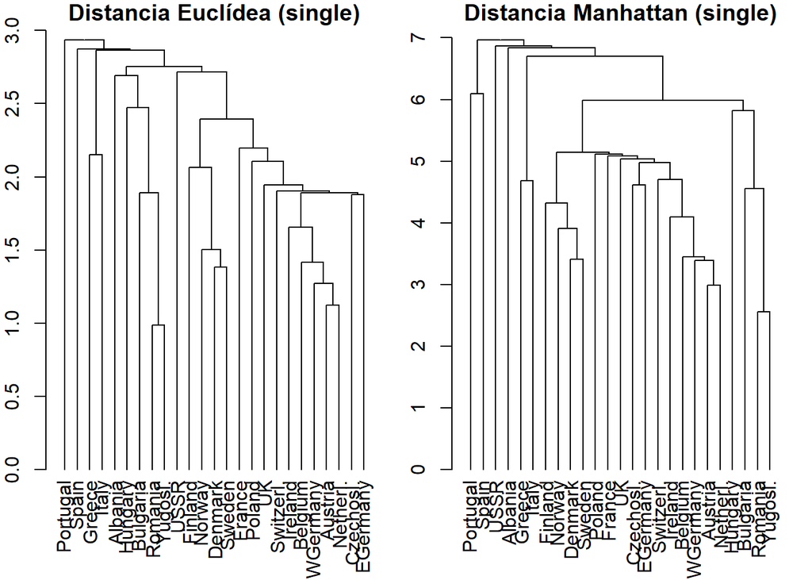

```r
par(mfrow = c(1, 2), mar = c(4, 2, 1, 1))
plot(
  as.dendrogram(hclust(proteindata.dist.euclidean, method = "single")),
  main = "Distancia Euclídea (single)")
plot(
  as.dendrogram(hclust(proteindata.dist.manhattan, method = "single")),
  main ="Distancia Manhattan (single)")
```

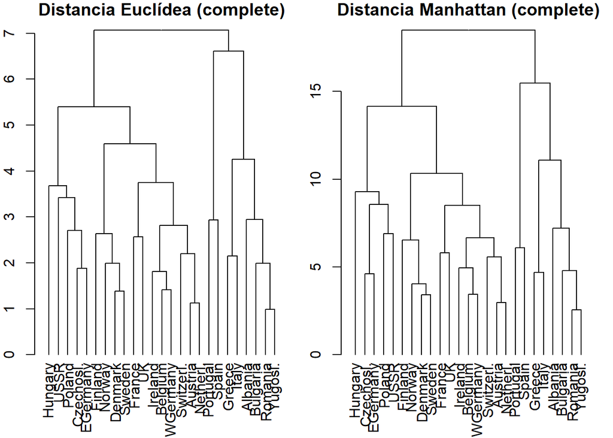

```r
par(mfrow = c(1, 2), mar = c(4, 2, 1, 1))
plot(
  as.dendrogram(hclust(proteindata.dist.euclidean, method = "complete")),
  main = "Distancia Euclídea (complete)")
plot(
  as.dendrogram(hclust(proteindata.dist.manhattan, method = "complete")),
  main ="Distancia Manhattan (complete)")
```

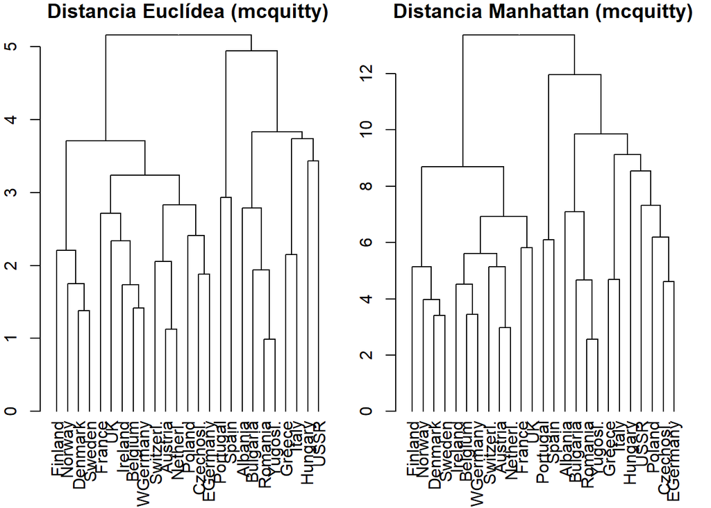

```r
par(mfrow = c(1, 2), mar = c(4, 2, 1, 1))
plot(
  as.dendrogram(hclust(proteindata.dist.euclidean, method = "mcquitty")),
  main = "Distancia Euclídea (mcquitty)")
plot(
  as.dendrogram(hclust(proteindata.dist.manhattan, method = "mcquitty")),
  main ="Distancia Manhattan (mcquitty)")
```

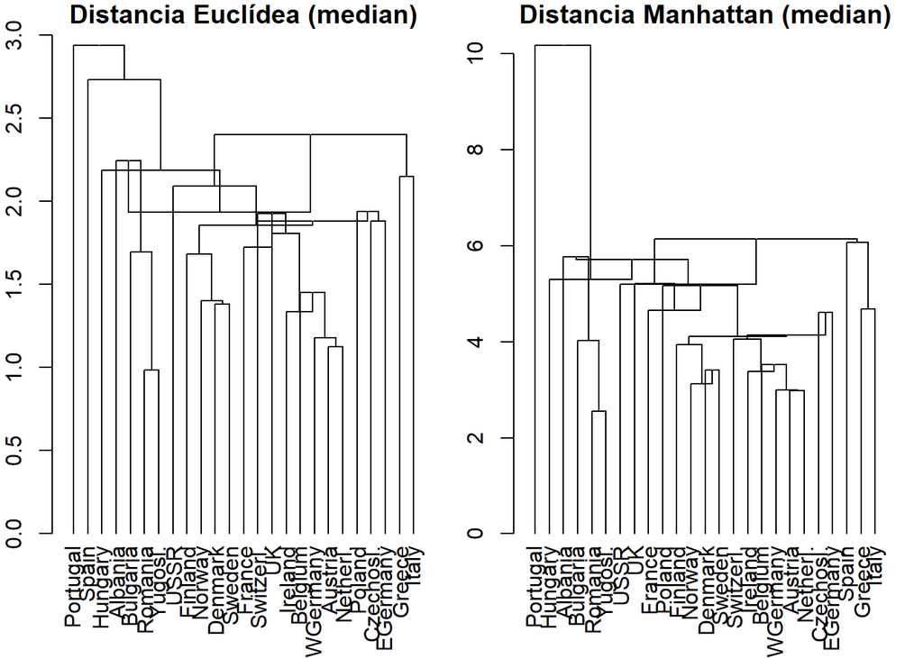

```r
par(mfrow = c(1, 2), mar = c(4, 2, 1, 1))
plot(
  as.dendrogram(hclust(proteindata.dist.euclidean, method = "median")),
  main = "Distancia Euclídea (median)")
plot(
  as.dendrogram(hclust(proteindata.dist.manhattan, method = "median")),
  main ="Distancia Manhattan (median)")
```

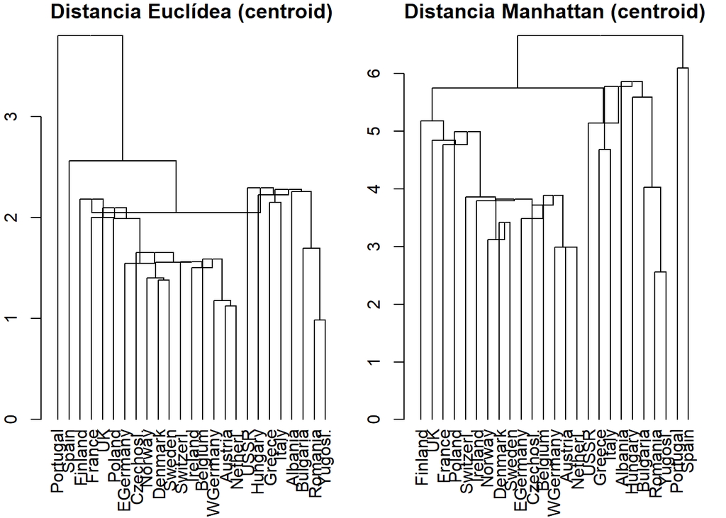

```r
par(mfrow = c(1, 2), mar = c(4, 2, 1, 1))
plot(
  as.dendrogram(hclust(proteindata.dist.euclidean, method = "centroid")),
  main = "Distancia Euclídea (centroid)")
plot(
  as.dendrogram(hclust(proteindata.dist.manhattan, method = "centroid")),
  main ="Distancia Manhattan (centroid)")
```

**Apartado 3**

Seleccionamos el método *average* con las distancias Manhattan y euclídea. Mostramos los dos dendogramas resultado de aplicar el clustering jerárquico.

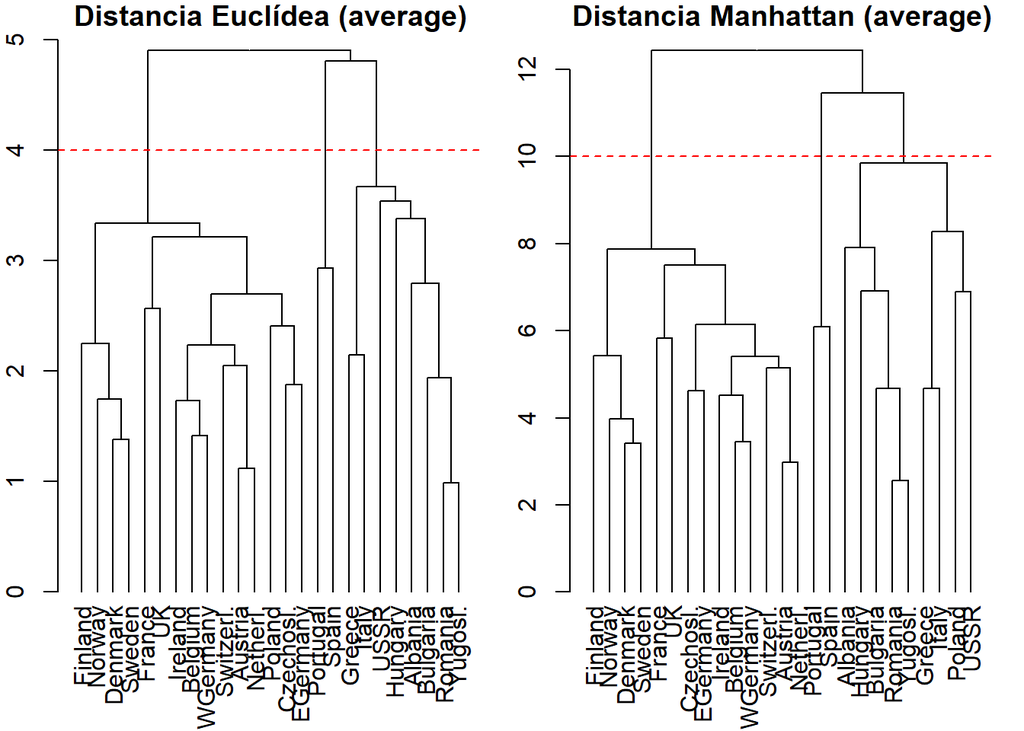

```r
par(mfrow = c(1, 2), mar = c(4, 2, 1, 1))
plot(
  as.dendrogram(hclust(proteindata.dist.euclidean, method = "average")),
  main = "Distancia Euclídea (average)")
abline(h=4, col="red", lty=2)

plot(
  as.dendrogram(hclust(proteindata.dist.manhattan, method = "average")),
  main ="Distancia Manhattan (average)")
abline(h=10, col="red", lty=2)
```

Los clústers generados a partir de ambas distancias son diferentes desde la primera división de países. Esto se puede ver a través del ejemplo de Polonia, que para la distancia euclídea se va al cluster de la izquierda mientras que para la distancia Manhattan se va al cluster de la derecha.

Cuanto más se baja en el dendograma más diferencias hay entro los distintos clusters generados a través de ambas distancias.

**Apartado 4**

Para realizar el clustering jerárquico por atributos bastaría con transponer el DataFrame con el que estamos trabajando.

```r
proteindata.scaled.t <- data.frame(t(proteindata.scaled[-1]))
colnames(proteindata.scaled.t) <- row.names(proteindata.scaled)

# Mostramos el resultado por pantalla
proteindata.scaled.t
```

|  | Albania | Austria | Belgium | Bulgaria | Czechosl. | Denmark | EGermany | Finland | France | Greece | Hungary | Ireland | Italy | Netherl. | Norway | Poland | Portugal | Romania | Spain | Sweden | Switzerl. | UK | USSR | WGermany | Yugosl. |
| --- | --- | --- | --- | --- | --- | --- | --- | --- | --- | --- | --- | --- | --- | --- | --- | --- | --- | --- | --- | --- | --- | --- | --- | --- | --- |
| WhiteMeat | -1.7584889 | 1.65237315 | 0.38006748 | -0.51325352 | 0.94854448 | 0.7861225 | 1.0026851 | -0.8110272 | 0.5424895 | -1.32536352 | 1.21924781 | 0.5695598 | -0.75688652 | 1.54409181 | -0.8651679 | 0.6237005 | -1.1358712 | -0.4320425 | -1.2170822 | -0.02598752 | 0.5966301 | -0.594464520 | -0.89223819 | 1.2463181 | -0.7839569 |
| Eggs | -2.1796385 | 1.22045441 | 1.04150215 | -1.19540109 | -0.12168754 | 0.6835976 | 0.6835976 | -0.2111637 | 0.3256931 | -0.12168754 | -0.03221141 | 1.5783589 | -0.03221141 | 0.59412150 | -0.2111637 | -0.2111637 | -1.6427817 | -1.2848772 | 0.1467409 | 0.50464537 | 0.1467409 | 1.578358929 | -0.74802044 | 1.0415022 | -1.5533056 |
| Milk | -1.1557381 | 0.39237676 | 0.05460623 | -1.24018077 | -0.64908235 | 1.1101391 | -0.8461152 | 2.3345573 | 0.3360817 | 0.06868001 | -1.04314796 | 1.2227293 | -0.48019709 | 0.88495877 | 0.8708850 | 0.3079341 | -1.7186890 | -0.8461152 | -1.1979595 | 1.06791780 | 0.9412539 | 0.490893160 | -0.07205771 | 0.2375653 | -1.0712955 |
| Fish | -1.2002821 | -0.64187467 | 0.06348211 | -0.90638347 | -0.67126454 | 1.6505349 | 0.3279909 | 0.4455504 | 0.4161605 | 0.47494024 | -1.17089226 | -0.6124848 | -0.25980642 | -0.52431521 | 1.5917551 | -0.3773659 | 2.9142991 | -0.9651632 | 0.7982288 | 0.94517809 | -0.5830949 | 0.004702379 | -0.37736588 | -0.2598064 | -1.0827227 |
| Cereals | 0.9159176 | -0.38706904 | -0.51463417 | 2.22801606 | 0.18697403 | -0.9428885 | -0.6968701 | -0.5419696 | -0.3779572 | 0.86124684 | 0.71545813 | -0.7515408 | 0.41476890 | -0.89732955 | -0.8426588 | 0.3509863 | -0.4781870 | 1.5810786 | -0.2777275 | -1.16157160 | -0.6057521 | -0.724205448 | 1.03437094 | -1.2435778 | 2.1551217 |
| Starch | -2.2495772 | -0.41368721 | 0.87143577 | -1.94359551 | 0.44306145 | 0.3206688 | 1.3610064 | 0.5042578 | 0.3206688 | -1.27043586 | -0.16890188 | 1.1774174 | -1.33163219 | -0.04650921 | 0.1982761 | 0.9938284 | 0.9938284 | -0.7196689 | 0.8714358 | -0.35249087 | -0.9032579 | 0.259472449 | 1.29981010 | 0.5654541 | -0.7808652 |
| Nuts | 1.2227536 | -0.89238857 | -0.48950434 | 0.31626412 | -0.99310963 | -1.1945517 | -1.1441912 | -1.0434702 | -0.3384228 | 2.38104581 | 1.17239311 | -0.7413070 | 0.61842730 | -0.64058593 | -0.7413070 | -0.5398649 | 0.8198694 | 1.1220326 | 1.4241958 | -0.84202804 | -0.3384228 | 0.165182535 | 0.16518253 | -0.7916675 | 1.3234747 |
| FruitVeg | -1.3504051 | 0.09091397 | -0.07539207 | 0.03547862 | -0.07539207 | -0.9623576 | -0.2971335 | -1.5167111 | 1.3104916 | 1.31049162 | 0.03547862 | -0.6851809 | 1.42136232 | -0.24169812 | -0.7960516 | 1.3659270 | 2.0865865 | -0.7406162 | 1.6985391 | -1.18409903 | 0.4235261 | -0.463439508 | -0.68518090 | -0.1862628 | -0.5188749 |

Una vez hecho esto se puede realizar el clustering igual que antes.

[figure not shown]

```r
# Calculamos la matriz de distancias
proteindata.dist.t <- dist(proteindata.scaled.t, method = "euclidean")

# Ejecutamos el clustering
plot(
  as.dendrogram(hclust(proteindata.dist.t, method = "average")),
  main ="Distancia Manhattan (average)")
```

Esto nos puede servir para observar las similitudes entre los distintos atributos. De esta manera nos podemos hacer una idea de que tipo de alimentos tienen unas cantidades similares de proteína.

## Ejercicio 4

**1. Cambia el parámetro `method` de la función `hclust()` y obtén los distintos dendrogramas utilizando como medida de distancia el índice de correlación de Pearson. Compara los resultados.**

**2. Genera los gráficos correspondientes a los distintos dendrogramas junto a sus heatmaps.**

**3. Prueba a generar distintos dendrogramas a través de la función pvclust modificando las funciones de distancia y resalta aquellos clusters con un p-valor mayor.**

**4. Elige, a tu criterio, la mejor partición e intenta interpretar los resultados.**

**Apartado 1**

Obtenemos la matriz de distancias utilizando el coeficiente de correlación de Pearson.

```r
cor.pe <- cor(t(as.matrix(proteindata.scaled)), method = c("pearson"))
proteindata.dist.pearson <- as.dist(1 - cor.pe)
```

Obtenemos los distintos dendogramas usando esa medida.

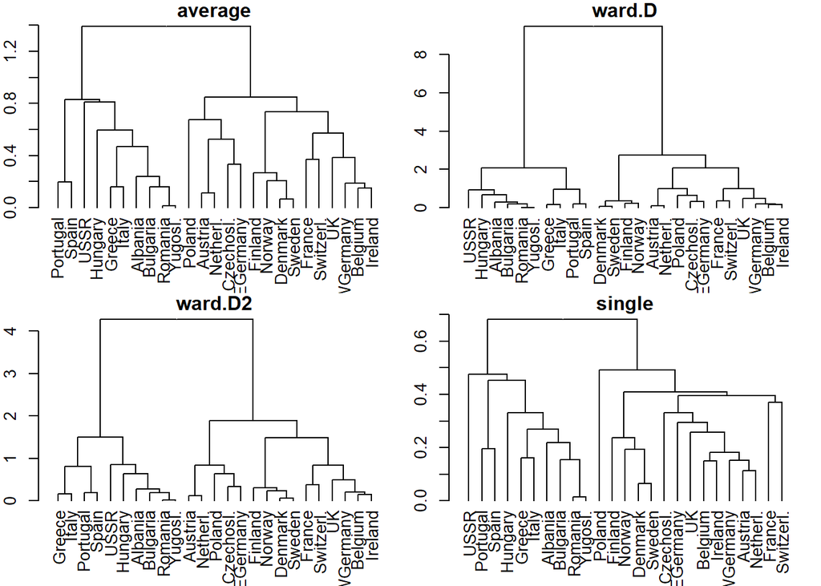

```r
par(mfrow = c(2, 2), mar = c(4, 2, 1, 1))
plot(
  as.dendrogram(hclust(proteindata.dist.pearson, method = "average")),
  main = "average")
plot(
  as.dendrogram(hclust(proteindata.dist.pearson, method = "ward.D")),
  main ="ward.D")
plot(
  as.dendrogram(hclust(proteindata.dist.pearson, method = "ward.D2")),
  main = "ward.D2")
plot(
  as.dendrogram(hclust(proteindata.dist.pearson, method = "single")),
  main = "single")
```

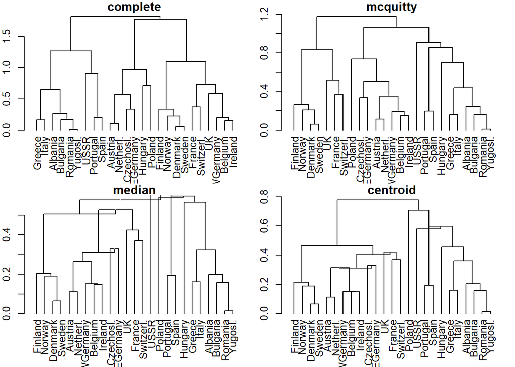

```r
par(mfrow = c(2, 2), mar = c(4, 2, 1, 1))
plot(
  as.dendrogram(hclust(proteindata.dist.pearson, method = "complete")),
  main = "complete")
plot(
  as.dendrogram(hclust(proteindata.dist.pearson, method = "mcquitty")),
  main = "mcquitty")
plot(
  as.dendrogram(hclust(proteindata.dist.pearson, method = "median")),
  main = "median")
plot(
  as.dendrogram(hclust(proteindata.dist.pearson, method = "centroid")),
  main = "centroid")
```

**Apartado 2**

Ahora generamos los gráficos correspondientes a los distintos dendogramas junto a sus *heatmaps*.

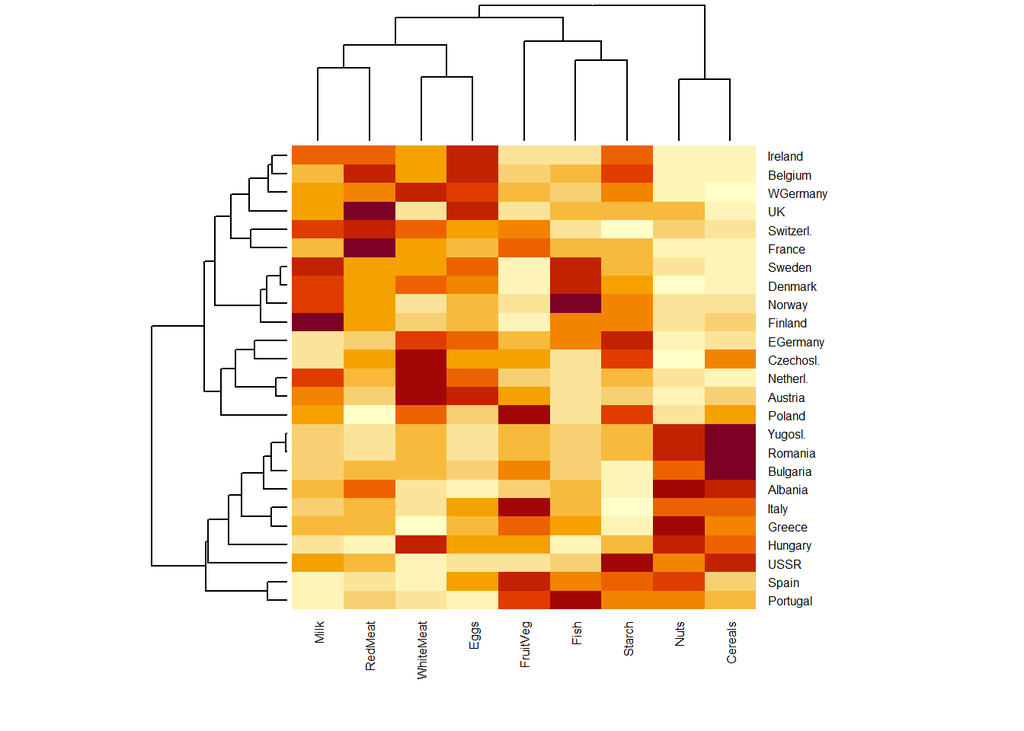

```r
heatmap(
  as.matrix(proteindata.scaled),
  Rowv = as.dendrogram(hclust(proteindata.dist.pearson, method = "average")),
  cexRow = .6,
  cexCol = .6
)
```

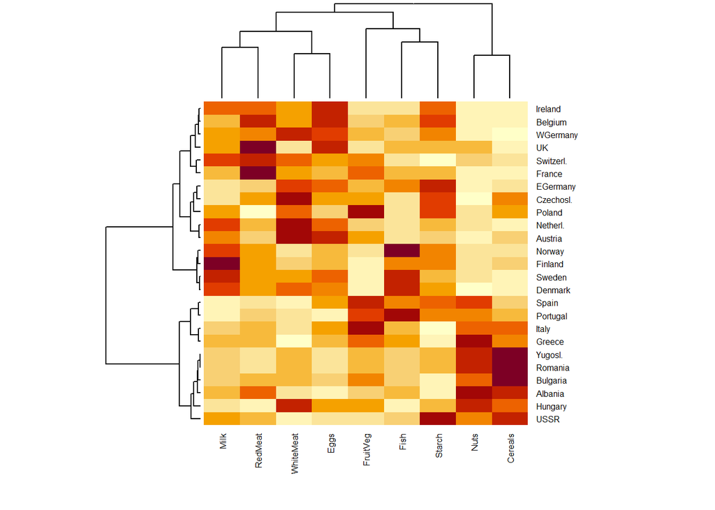

```r
heatmap(
  as.matrix(proteindata.scaled),
  Rowv = as.dendrogram(hclust(proteindata.dist.pearson, method = "ward.D")),
  cexRow = .6,
  cexCol = .6
)
```

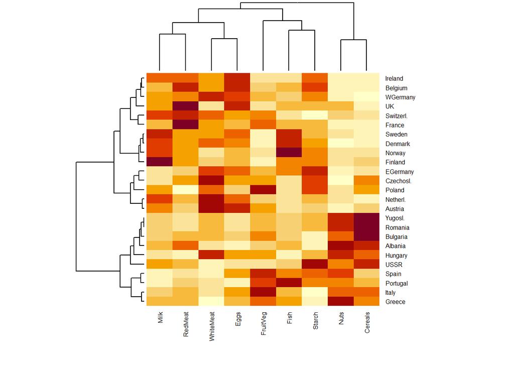

```r
heatmap(
  as.matrix(proteindata.scaled),
  Rowv = as.dendrogram(hclust(proteindata.dist.pearson, method = "ward.D2")),
  cexRow = .6,
  cexCol = .6
)
```

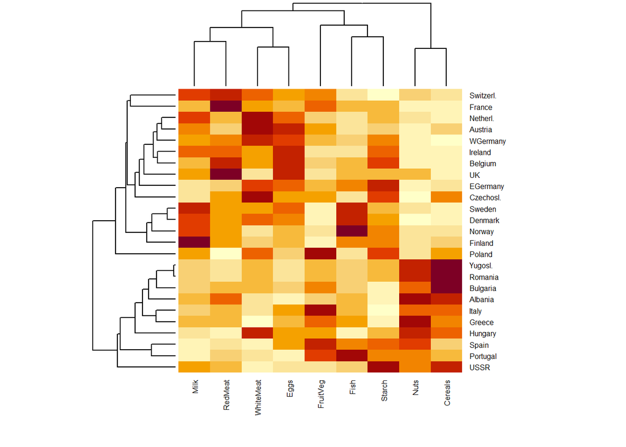

```r
heatmap(
  as.matrix(proteindata.scaled),
  Rowv = as.dendrogram(hclust(proteindata.dist.pearson, method = "single")),
  cexRow = .6,
  cexCol = .6
)
```

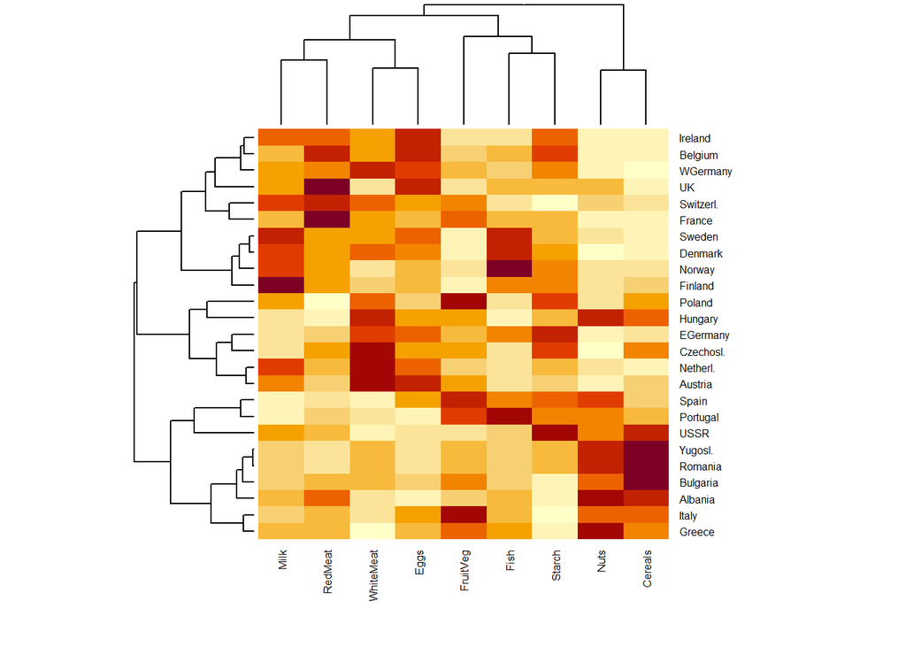

```r
heatmap(
  as.matrix(proteindata.scaled),
  Rowv = as.dendrogram(hclust(proteindata.dist.pearson, method = "complete")),
  cexRow = .6,
  cexCol = .6
)
```

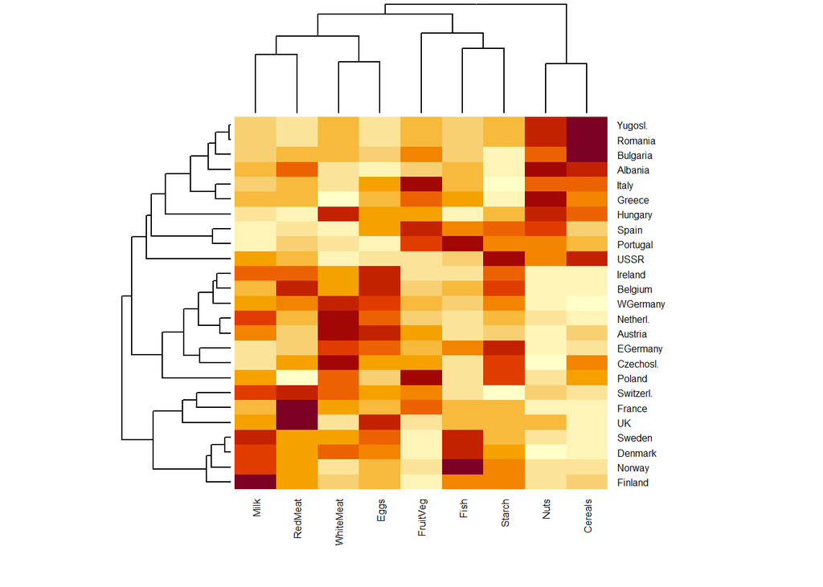

```r
heatmap(
  as.matrix(proteindata.scaled),
  Rowv = as.dendrogram(hclust(proteindata.dist.pearson, method = "mcquitty")),
  cexRow = .6,
  cexCol = .6
)
```

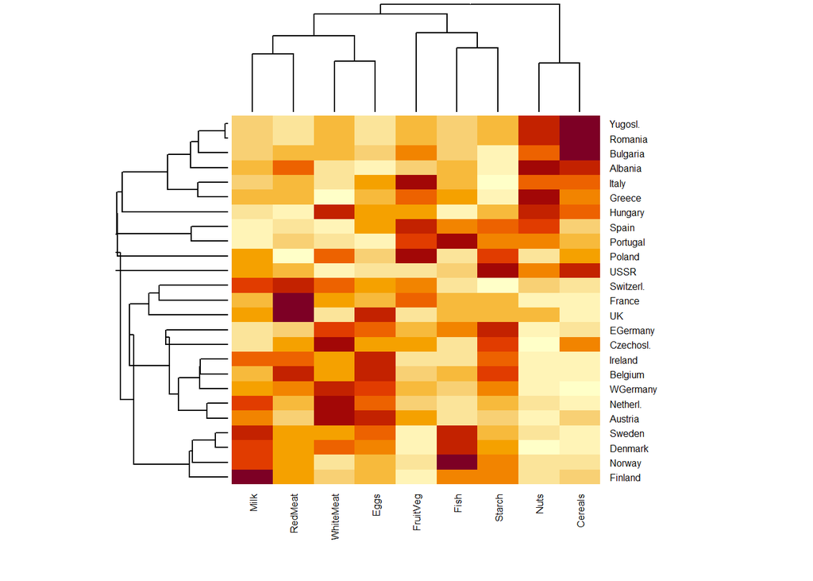

```r
heatmap(
  as.matrix(proteindata.scaled),
  Rowv = as.dendrogram(hclust(proteindata.dist.pearson, method = "median")),
  cexRow = .6,
  cexCol = .6
)
```

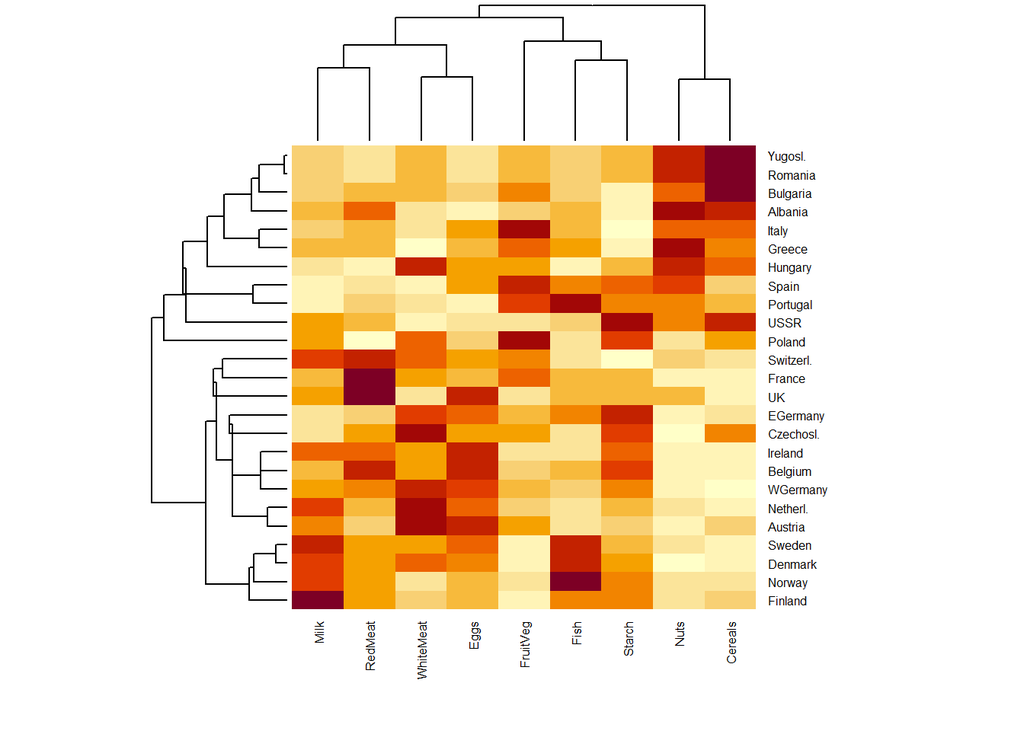

```r
heatmap(
  as.matrix(proteindata.scaled),
  Rowv = as.dendrogram(hclust(proteindata.dist.pearson, method = "centroid")),
  cexRow = .6,
  cexCol = .6
)
```

**Apartado 3**

Dejamos el método para generar el dendograma igual que en el ejemplo del enunciado (**complete**) y modificamos las funciones de distancia.

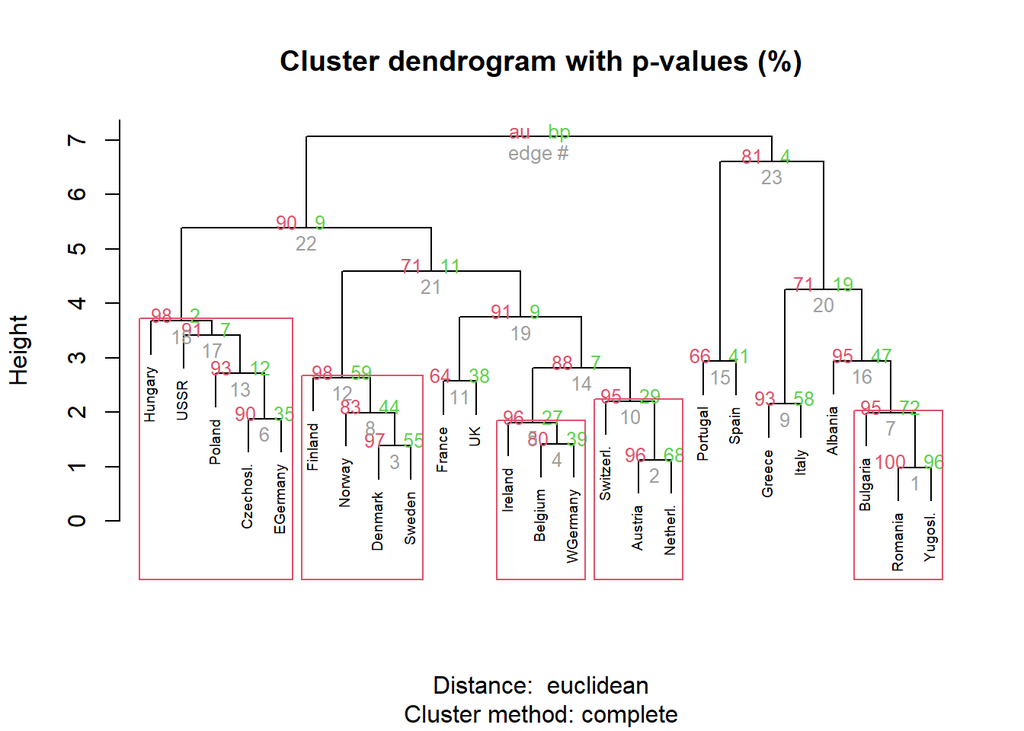

```r
set.seed(123)

# Distancia euclidea
plot <- pvclust(t(proteindata.scaled),
                method.hclust = "complete",
                method.dist = "euclidean")
plot(plot, cex = .6)
pvrect(plot, alpha = 0.95)
```

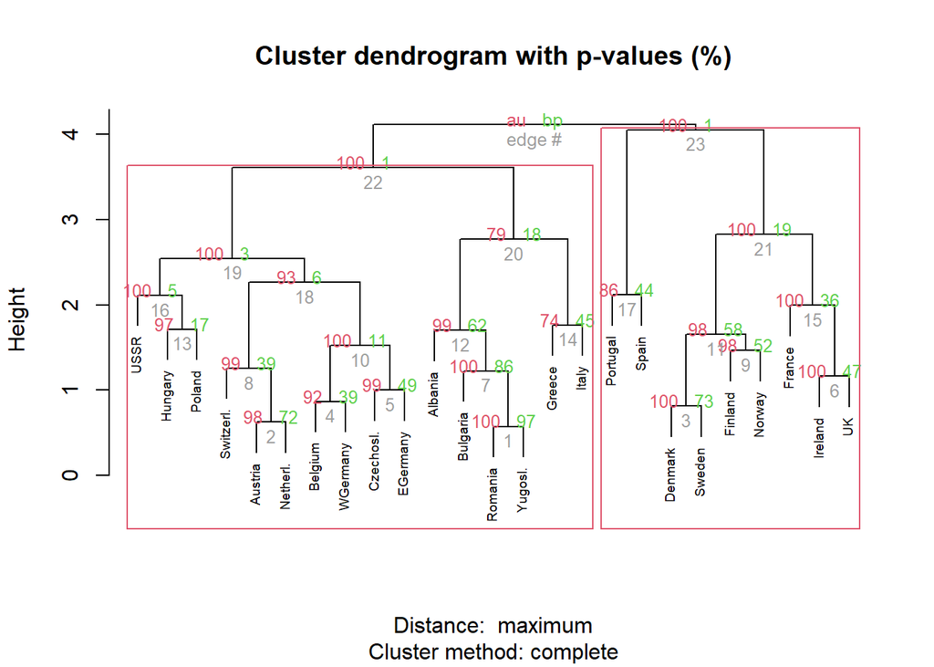

```r
set.seed(123)

# Distancia maximum
plot <- pvclust(t(proteindata.scaled),
                method.hclust = "complete",
                method.dist = "maximum")
plot(plot, cex = .6)
pvrect(plot, alpha = 0.95)
```

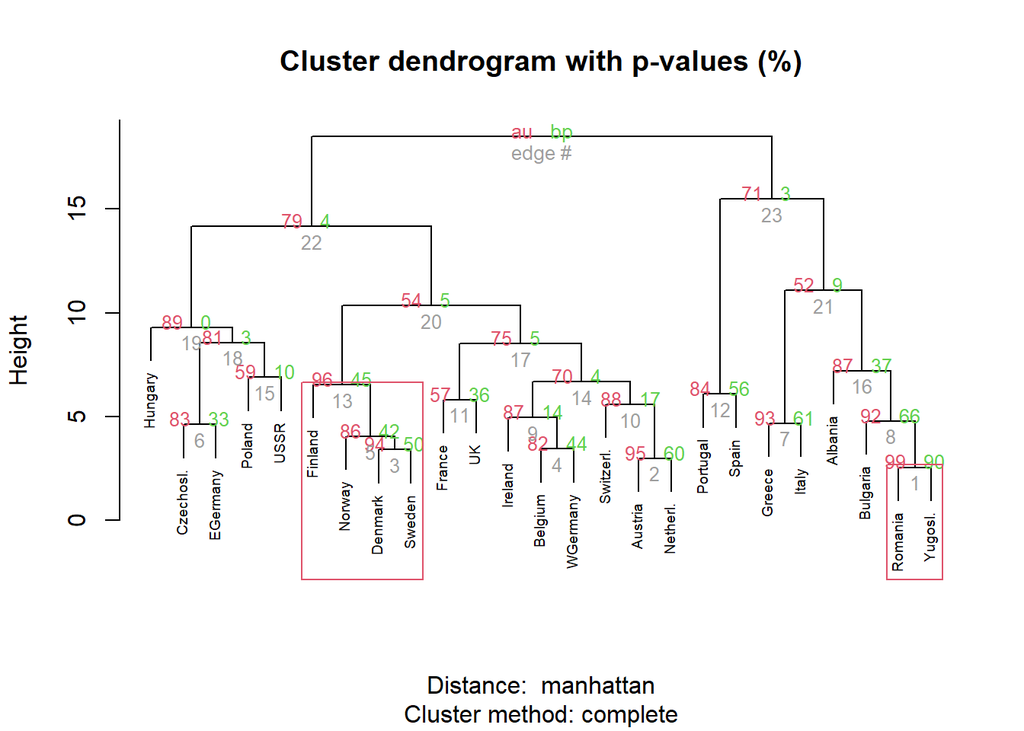

```r
set.seed(123)

# Distancia manhattan
plot <- pvclust(t(proteindata.scaled),
                method.hclust = "complete",
                method.dist = "manhattan")
plot(plot, cex = .6)
pvrect(plot, alpha = 0.95)
```

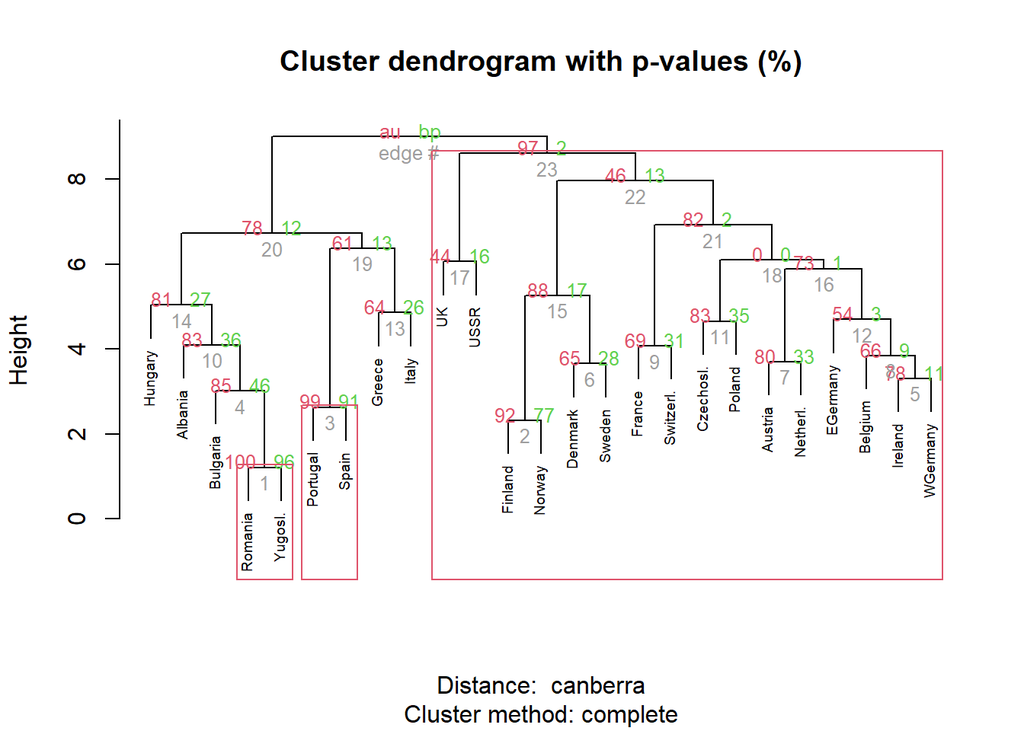

```r
set.seed(123)

# Distancia canberra
plot <- pvclust(t(proteindata.scaled),
                method.hclust = "complete",
                method.dist = "canberra")
plot(plot, cex = .6)
pvrect(plot, alpha = 0.95)
```

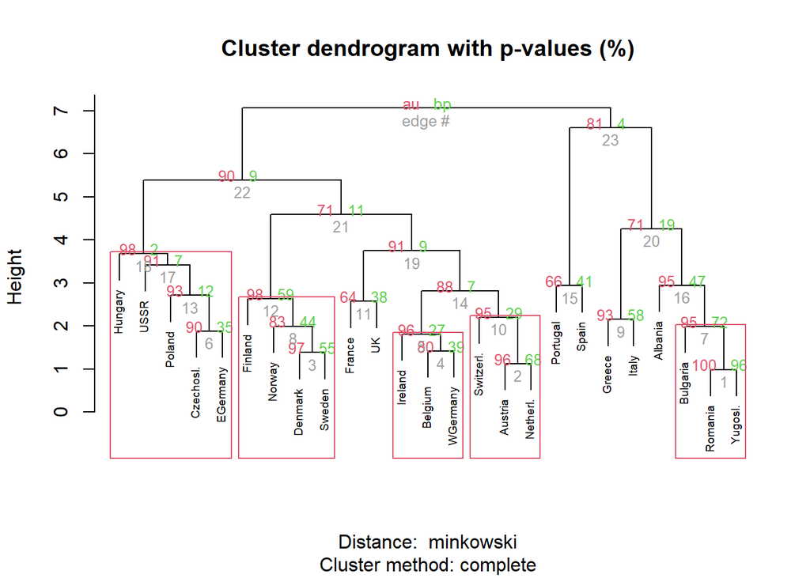

```r
set.seed(123)

# Distancia minkowski
plot <- pvclust(t(proteindata.scaled),
                method.hclust = "complete",
                method.dist = "minkowski")
plot(plot, cex = .6)
pvrect(plot, alpha = 0.95)
```

**Apartado 4**

Las dos distancias que obtienen un número mayor de clusters que estén soportados por los datos son la distancia *euclídea* y la distancia *mikowski*.

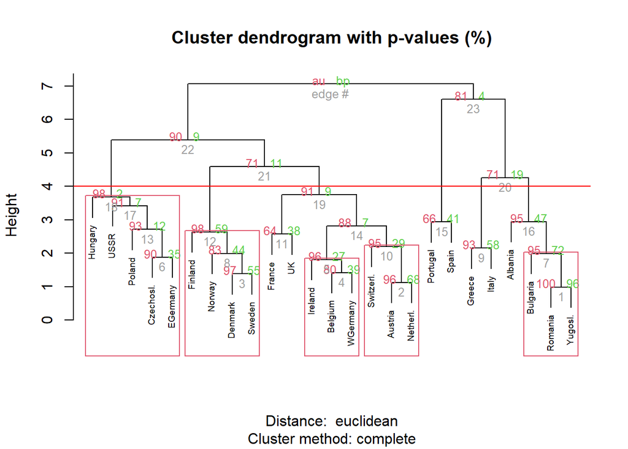

```r
set.seed(123)

# Distancia euclidea
plot <- pvclust(t(proteindata.scaled),
                method.hclust = "complete",
                method.dist = "euclidean")
plot(plot, cex = .6)
abline(h = 4, col="red")
pvrect(plot, alpha = 0.95)
```

Si realizamos el corte a una altura de 4, con el uso de esta distancia encontramos **cinco clusters** que superan el umbral del 95% de soporte de los clusters por los datos.

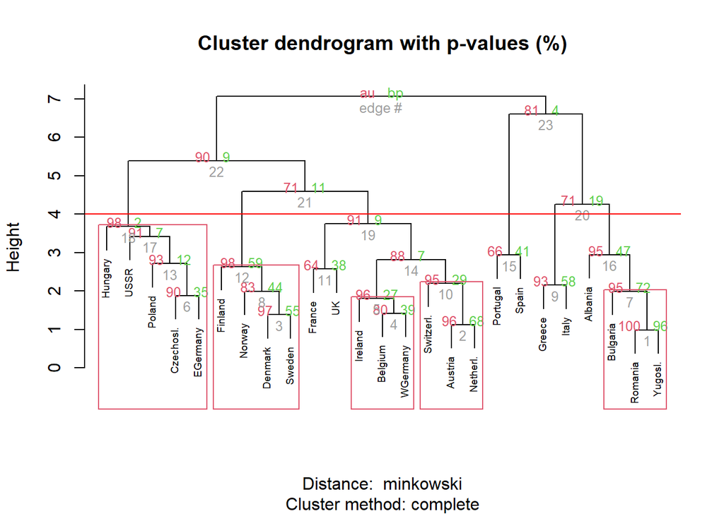

```r
set.seed(123)

# Distancia minkowski
plot <- pvclust(t(proteindata.scaled),
                method.hclust = "complete",
                method.dist = "minkowski")
plot(plot, cex = .6)
abline(h = 4, col="red")
pvrect(plot, alpha = 0.95)
```

Para el caso de la distancia *mikowski* realizando el corte a la misma distancia de 4, también encontramos **cinco clusters** con un *p-value* superior al 0,95. De hecho los clusters encontrados por esta distancia y la *euclídea* son los mismos. Por tanto, ambos representan la mejor partición de los datos.